# The Math Behind the Training Loop

Workshop: Linear algebra & calculus from scratch — deriving the gradient-descent update used in HW1  
Spring 2026 · Faculty of Biotechnology and Food Engineering  
Technion — Israel Institute of Technology · TA: Mattan Hoory

← Workshops

## Why this workshop?

In Tutorial 1 we met **multiple linear regression** trained with **mini-batch gradient descent**, and in **HW1** you implemented the training loop yourself. The heart of that loop is these few lines:

```python
for epoch in range(self.n_epochs):
    idx = rng.permutation(n)                 # shuffle each epoch
    for start in range(0, n, self.batch_size):
        bi = idx[start:start + self.batch_size]
        Xb, yb = X[bi], y[bi]
        B = Xb.shape[0]
        resid  = self._linear(Xb) - yb       # (B,)   r = Xw + b - y
        grad_w = (2.0 / B) * (Xb.T @ resid)  # (m,)   ∂L/∂w
        grad_b = (2.0 / B) * resid.sum()     # scalar ∂L/∂b
        self.w -= self.lr * grad_w           # update rule (w)
        self.b -= self.lr * grad_b           # update rule (b)
```

Every symbol here — `Xb.T @ resid`, the `2/B`, the minus sign in the update — comes from two pieces of math: **linear algebra** (what `@` and `.T` mean) and **calculus** (where the gradient comes from). This workshop builds both **from scratch** and finishes by **deriving each line above**.

**Goal**

By the end you will be able to look at any line of that loop and say *exactly* which definition or rule it implements — and verify it numerically in code.

We use the notation from Tutorial 1: the model is
$$h_\theta(x) = w^\top x + b,\qquad \theta=(w,b),$$
and the loss is the **mean squared error (MSE)**.

```python
import numpy as np
import matplotlib.pyplot as plt
rng = np.random.default_rng(0)
np.set_printoptions(precision=3, suppress=True)
```

# 1 Part I — Linear algebra from scratch

## 1.1 Scalars, vectors, and notation

- A **scalar** is a single number, e.g. the learning rate $\eta = 0.001$.
- A **vector** is an ordered list of numbers. We write it as a column:
  $$x=\begin{bmatrix}x_1\\x_2\\\vdots\\x_m\end{bmatrix}\in\mathbb{R}^m .$$
  In HW1 one **sample** is a vector $x\in\mathbb{R}^{943}$ — the 943 landmark-gene expression values. The number of entries, $m$, is the vector’s **dimension**.

```python
x = np.array([2.0, -1.0, 3.0])     # a vector in R^3
print("x      =", x)
print("shape  =", x.shape, "  dimension m =", x.shape[0])
```

```
x      = [ 2. -1.  3.]
shape  = (3,)   dimension m = 3
```

### Two basic operations

**Addition** (same length, entry by entry) and **scalar multiplication** (scale every entry):
$$x+y=\begin{bmatrix}x_1+y_1\\\vdots\\x_m+y_m\end{bmatrix},\qquad
\alpha x=\begin{bmatrix}\alpha x_1\\\vdots\\\alpha x_m\end{bmatrix}.$$

```python
y = np.array([1.0, 1.0, 1.0])
print("x + y   =", x + y)
print("2 * x   =", 2 * x)
```

```
x + y   = [3. 0. 4.]
2 * x   = [ 4. -2.  6.]
```

These two operations are *exactly* what the update rule `self.w -= self.lr * grad_w` uses: it scales the gradient vector by $\eta$ and subtracts it from $w$.

## 1.2 The dot product: the engine of the linear model

The **dot product** of two vectors of the same length is a single **scalar**:
$$w^\top x \;=\; \sum_{j=1}^{m} w_j\,x_j \;=\; w_1x_1+w_2x_2+\dots+w_mx_m .$$

```python
w = np.array([0.5, -2.0, 1.0])
print("w·x (loop)  =", sum(w[j]*x[j] for j in range(len(x))))
print("w·x (numpy) =", w @ x)          # the @ operator = dot product here
```

```
w·x (loop)  = 6.0
w·x (numpy) = 6.0
```

This is the entire linear model for **one** sample:
$$\boxed{\,h_\theta(x) = w^\top x + b = \Big(\sum_{j=1}^m w_j x_j\Big) + b\,}$$
Each weight $w_j$ says how much gene $j$ pushes the prediction up or down; $b$ is a constant offset (the **bias**).

**Exercise 1 — predict one sample by hand**

With $w=[0.5,-2,1]^\top$, $b=0.1$, and $x=[2,-1,3]^\top$, compute $h_\theta(x)$.

**Solution.** $w^\top x = (0.5)(2)+(-2)(-1)+(1)(3)=1+2+3=6$, so $h_\theta(x)=6+0.1=6.1$.

```python
print(w @ x + 0.1)
```

```
6.1
```

## 1.3 Matrices and the matrix–vector product

A **matrix** stacks vectors into a grid. In HW1 a **batch** of $B$ samples is a matrix
$$X=\begin{bmatrix}\text{— }x_1^\top\text{ —}\\\text{— }x_2^\top\text{ —}\\\vdots\\\text{— }x_B^\top\text{ —}\end{bmatrix}\in\mathbb{R}^{B\times m},$$
i.e. **row $i$ is sample $i$**. The full dataset is $X\in\mathbb{R}^{n\times m}$.

To predict for *all* rows at once we use the **matrix–vector product** $Xw$: row $i$ of the result is the dot product of row $i$ of $X$ with $w$.
$$(Xw)_i=\sum_{j=1}^m X_{ij}\,w_j = x_i^\top w .$$
So $Xw\in\mathbb{R}^{B}$ holds the linear part of all $B$ predictions, and the whole batch prediction is $\hat y = Xw + b$ (the scalar $b$ is added to every entry — **broadcasting**).

```python
X = np.array([[2.0, -1.0, 3.0],
              [0.0,  1.0, 1.0],
              [1.0,  1.0, 0.0],
              [-1.0, 0.0, 2.0]])   # 4 samples (rows), 3 features (cols): shape (4,3)
b = 0.1
preds = X @ w + b                  # shape (4,) — one prediction per sample
print("X shape   :", X.shape)
print("X @ w + b :", preds)
# sanity check: row 0 must equal the by-hand answer from Exercise 1
print("row 0 == 6.1 ?", np.isclose(preds[0], 6.1))
```

```
X shape   : (4, 3)
X @ w + b : [ 6.1 -0.9 -1.4  1.6]
row 0 == 6.1 ? True
```

### Shapes must line up

A product $A\,v$ is only defined when the **inner dimensions match**:
$$\underbrace{X}_{B\times m}\;\underbrace{w}_{m\times 1}\;\Rightarrow\;\underbrace{Xw}_{B\times 1}.$$
Checking shapes is the fastest way to debug ML code. In the HW1 loop:

| symbol | meaning | shape |
| --- | --- | --- |
| `Xb` | batch of inputs | $B\times m$ |
| `w` | weights | $m$ |
| `Xb @ w` | linear scores | $B$ |
| `resid` | residuals $\hat y-y$ | $B$ |
| `Xb.T` | transpose of `Xb` | $m\times B$ |
| `Xb.T @ resid` | gradient direction | $m$ |

## 1.4 The transpose, and where $X^\top$ comes from

The **transpose** $X^\top$ flips rows and columns: if $X$ is $B\times m$ then $X^\top$ is $m\times B$, with $(X^\top)_{ji}=X_{ij}$.

```python
print("X   shape:", X.shape)
print("X.T shape:", X.T.shape)
print(X.T)
```

```
X   shape: (4, 3)
X.T shape: (3, 4)
[[ 2.  0.  1. -1.]
 [-1.  1.  1.  0.]
 [ 3.  1.  0.  2.]]
```

Why does the gradient line use $X^\top$? Because we will need, for **each feature $j$**, the sum over all samples of (that feature’s value $\times$ the residual):
$$\big(X^\top r\big)_j=\sum_{i=1}^{B} X_{ij}\,r_i .$$
That is precisely $m$ dot products — one per feature — packed into a single matrix–vector product. Keep this identity in mind; it is the whole reason `Xb.T` appears in `grad_w`. We’ll derive it properly in Section 3.2.

```python
r = np.array([1.0, -1.0, 0.5, 2.0])   # a dummy residual vector, shape (4,)
# feature-by-feature sum, the slow way:
manual = np.array([sum(X[i, j]*r[i] for i in range(X.shape[0]))
                   for j in range(X.shape[1])])
print("manual   X^T r :", manual)
print("numpy  X.T @ r :", X.T @ r)
```

```
manual   X^T r : [ 0.5 -1.5  6. ]
numpy  X.T @ r : [ 0.5 -1.5  6. ]
```

# 2 Part II — Calculus from scratch

## 2.1 Functions and the derivative

A **function** $f$ turns an input into an output, e.g. $f(t)=t^2$. The **derivative** $f'(t)=\frac{df}{dt}$ is the **slope** of $f$ at $t$ — how fast the output changes when the input nudges. Formally it is a limit:
$$f'(t)=\lim_{h\to 0}\frac{f(t+h)-f(t)}{h}.$$
Intuition for gradient descent: the derivative points **uphill**. To *decrease* $f$, step in the **opposite** direction — that single fact is the minus sign in the update rule.

```python
f = lambda t: t**2
t0, h = 3.0, 1e-6
slope_numeric = (f(t0 + h) - f(t0)) / h     # finite-difference estimate of f'(3)
print(f"numeric slope at t=3 : {slope_numeric:.4f}")
print(f"exact   slope 2*t    : {2*t0:.4f}")  # we'll justify 2*t below
```

```
numeric slope at t=3 : 6.0000
exact   slope 2*t    : 6.0000
```

## 2.2 The handful of rules we actually need

| rule | statement |
| --- | --- |
| Power | $\dfrac{d}{dt}\,t^k = k\,t^{k-1}$ |
| Constant factor | $\dfrac{d}{dt}\,[c\,f(t)] = c\,f'(t)$ |
| Sum | $\dfrac{d}{dt}\,[f+g] = f' + g'$ |
| **Chain rule** | $\dfrac{d}{dt}\,f(g(t)) = f'(g(t))\,g'(t)$ |

The **chain rule** is the star of the show. The squared error is a *composition*: square *of* (prediction minus target). Let
$$u(t)=a t + c,\qquad g(t)=\big(u(t)\big)^2 .$$
Then by the chain rule (outer $=(\cdot)^2$ with derivative $2(\cdot)$, inner $u$ with derivative $a$):
$$\boxed{\,g'(t)=2\,(a t + c)\cdot a\,}$$

```python
a, c = 2.0, -5.0
g = lambda t: (a*t + c)**2
t0 = 1.3
num = (g(t0+1e-6) - g(t0))/1e-6
ana = 2*(a*t0 + c)*a
print(f"chain-rule check:  numeric {num:.4f}  vs  analytic {ana:.4f}")
```

```
chain-rule check:  numeric -9.6000  vs  analytic -9.6000
```

Notice the shape of the answer: **2 × (residual) × (inner slope)**. Every gradient in this workshop is an instance of this one pattern.

## 2.3 Partial derivatives and the gradient

The loss depends on **many** parameters at once ($w_1,\dots,w_m,b$). A **partial derivative** $\frac{\partial L}{\partial w_j}$ is just the ordinary derivative with respect to one parameter while **holding the others fixed**.

Stacking all partials into a vector gives the **gradient**:
$$\nabla_w L=\Big[\tfrac{\partial L}{\partial w_1},\,\tfrac{\partial L}{\partial w_2},\,\dots,\,\tfrac{\partial L}{\partial w_m}\Big]^\top .$$
The gradient is the direction of **steepest increase** of $L$. Gradient descent takes a small step **against** it:
$$\boxed{\,\theta \leftarrow \theta - \eta\,\nabla_\theta L\,}$$

# 3 Part III — Putting it together: deriving the MSE gradient

## 3.1 Warm-up: the single-feature case (Tutorial 1)

Tutorial 1 used a one-feature model $h(x)=\theta_1 x+\theta_0$ with loss
$$\mathcal{L}(\theta_0,\theta_1)=\frac1N\sum_{i=1}^N(\theta_1 x_i+\theta_0-y_i)^2 .$$
Apply the chain-rule pattern $g'=2\cdot(\text{residual})\cdot(\text{inner slope})$ to each summand, with residual $r_i=\theta_1 x_i+\theta_0-y_i$:

- w.r.t. $\theta_0$, the inner slope $\partial r_i/\partial\theta_0=1$:
  $$\frac{\partial \mathcal{L}}{\partial \theta_0}=\frac{2}{N}\sum_{i=1}^N(\theta_1 x_i+\theta_0-y_i).$$
- w.r.t. $\theta_1$, the inner slope $\partial r_i/\partial\theta_1=x_i$:
  $$\frac{\partial \mathcal{L}}{\partial \theta_1}=\frac{2}{N}\sum_{i=1}^N x_i\,(\theta_1 x_i+\theta_0-y_i).$$

These are exactly the two `grad` lines in the Tutorial 1 training loop. The bias partial sums the residuals; the weight partial sums *feature × residual*. **Hold on to that distinction** — it survives unchanged into the multi-feature case.

## 3.2 The general case: multiple linear regression

Now the HW1 model. We’ll do the whole derivation in **plain summation notation** — no matrices, no transpose, just sums, the chain rule, and the sum rule. It is the cleanest way to see where every term comes from. (The matrix-shorthand version is in the collapsed box at the end, for when you want the compact one-liner.)

**Step 1 — write the loss with sums.** A prediction is a sum over the $m$ features, so the residual for sample $i$ is
$$r_i=\Big(\sum_{k=1}^{m}X_{ik}\,w_k\Big)+b-y_i ,$$
and the mean squared error over a batch of $B$ samples is a **double sum**:
$$L(w_1,\dots,w_m,b)=\frac1B\sum_{i=1}^{B} r_i^{\,2}
=\frac1B\sum_{i=1}^{B}\Big(\sum_{k=1}^{m}X_{ik}\,w_k+b-y_i\Big)^{2}.$$
The summation index $k$ runs over *all* weights; $j$ (below) is the *one* weight we differentiate with respect to. Keeping the two letters separate is the whole trick.

**Step 2 — differentiate w.r.t. one weight $w_j$.** Differentiate the outer sum term by term (sum rule), applying the chain-rule pattern from Section 2.2 to each squared bracket (*outer $(\cdot)^2\to 2(\cdot)$, times inner slope*):
$$\frac{\partial L}{\partial w_j}
=\frac1B\sum_{i=1}^{B} 2\Big(\sum_{k=1}^{m}X_{ik}w_k+b-y_i\Big)\cdot
\frac{\partial}{\partial w_j}\Big(\sum_{k=1}^{m}X_{ik}w_k+b-y_i\Big).$$
The **inner derivative** is still pure sums. The terms $b$ and $y_i$ have no $w_j$ (slope $0$), and in $\sum_k X_{ik}w_k$ only the $k=j$ term contains $w_j$:
$$\frac{\partial}{\partial w_j}\sum_{k=1}^{m}X_{ik}w_k
=\sum_{k=1}^{m}X_{ik}\,\frac{\partial w_k}{\partial w_j}
=\sum_{k=1}^{m}X_{ik}\,\delta_{kj}=X_{ij},$$
where $\delta_{kj}=1$ if $k=j$ and $0$ otherwise (the weights are independent of one another). Substituting back, and recognizing the bracket as $r_i$:
$$\boxed{\;\frac{\partial L}{\partial w_j}=\frac{2}{B}\sum_{i=1}^{B} r_i\,X_{ij}\;}
\qquad j=1,\dots,m.$$
One scalar formula per weight: *twice the average, over the batch, of (feature $j$) × (residual)*.

**Step 3 — the bias, the same way.** Its inner slope is just its coefficient in $r_i$, namely $1$, so the feature factor drops out:
$$\boxed{\;\frac{\partial L}{\partial b}=\frac{2}{B}\sum_{i=1}^{B} r_i\;}$$
i.e. *twice the average residual* — no feature weighting, since $b$ shifts every prediction equally.

**Step 4 — the per-element update, and the code with no matrices.** Gradient descent updates each parameter on its own:
$$w_j \leftarrow w_j-\eta\,\frac{2}{B}\sum_{i=1}^{B} r_i\,X_{ij}\quad(\forall j),
\qquad
b \leftarrow b-\eta\,\frac{2}{B}\sum_{i=1}^{B} r_i .$$
Written literally, that is two nested loops — no matrix multiply anywhere:

```python
for j in range(m):
    grad_w[j] = (2.0/B) * sum(resid[i] * Xb[i, j] for i in range(B))
grad_b = (2.0/B) * sum(resid[i] for i in range(B))
```

**Step 5 — stack the partials and watch the matrix notation appear.** Step 2 gave us $m$ separate scalar formulas, one per weight. The **gradient** is just those $m$ numbers collected into a column vector. Let’s write them all out and factor the common $\frac2B$:
$$\nabla_w L=
\begin{bmatrix}\partial L/\partial w_1\\[3pt]\partial L/\partial w_2\\[3pt]\vdots\\[3pt]\partial L/\partial w_m\end{bmatrix}
=
\begin{bmatrix}\frac2B\sum_{i} r_i\,X_{i1}\\[3pt]\frac2B\sum_{i} r_i\,X_{i2}\\[3pt]\vdots\\[3pt]\frac2B\sum_{i} r_i\,X_{im}\end{bmatrix}
=\frac2B
\begin{bmatrix}\sum_{i} X_{i1}\,r_i\\[3pt]\sum_{i} X_{i2}\,r_i\\[3pt]\vdots\\[3pt]\sum_{i} X_{im}\,r_i\end{bmatrix}.$$
Now look at that last column **on its own**. Compute the matrix–vector product $X^\top r$ directly: row $j$ of $X^\top$ is column $j$ of $X$, i.e. $(X_{1j},X_{2j},\dots,X_{Bj})$, and dotting it with $r=(r_1,\dots,r_B)^\top$ gives
$$X^\top r=
\begin{bmatrix}
X_{11}&X_{21}&\cdots&X_{B1}\\
X_{12}&X_{22}&\cdots&X_{B2}\\
\vdots&\vdots&&\vdots\\
X_{1m}&X_{2m}&\cdots&X_{Bm}
\end{bmatrix}
\begin{bmatrix}r_1\\r_2\\\vdots\\r_B\end{bmatrix}
=
\begin{bmatrix}\sum_{i} X_{i1}\,r_i\\[3pt]\sum_{i} X_{i2}\,r_i\\[3pt]\vdots\\[3pt]\sum_{i} X_{im}\,r_i\end{bmatrix}.$$
The two columns are **identical, entry for entry** — the $j$-th component of both is $\sum_i X_{ij}r_i$. So the vector we built by hand from the sum-rule partials *is* $X^\top r$; we didn’t assume any matrix calculus, it simply fell out of stacking:
$$\boxed{\,\nabla_w L=\frac{2}{B}\,X^\top r\,}\;\Longleftrightarrow\;
\texttt{grad\_w = (2.0/B)*(Xb.T @ resid)} .$$
The same move on the bias: $\displaystyle\sum_{i} r_i=\mathbf 1^\top r$ (dotting $r$ with the all-ones vector), so
$$\boxed{\,\frac{\partial L}{\partial b}=\frac{2}{B}\sum_{i} r_i=\frac2B\,\mathbf 1^\top r\,}\;\Longleftrightarrow\;
\texttt{grad\_b = (2.0/B)*resid.sum()} .$$
That’s the whole bridge: the matrix form is the column of sum-formulas, rewritten as one product. It buys **compactness and speed** (a single BLAS call instead of the Python double loop of Step 4) — the math is line-for-line identical to Steps 2–3.

**Optional: the same derivation in matrix notation**

If you prefer to stay in vector/matrix land the whole way, here it is. Write the residual **vector** $r=Xw+b\mathbf 1-y\in\mathbb R^{B}$ and $L=\frac1B\lVert r\rVert_2^2$. Differentiating one weight,
$$\frac{\partial L}{\partial w_j}
=\frac1B\sum_{i=1}^B 2\,r_i\,\frac{\partial r_i}{\partial w_j},
\qquad
\frac{\partial r_i}{\partial w_j}
=\frac{\partial}{\partial w_j}\Big(\textstyle\sum_k X_{ik}w_k+b-y_i\Big)
=\sum_k X_{ik}\delta_{kj}=X_{ij}.$$
Hence $\dfrac{\partial L}{\partial w_j}=\dfrac{2}{B}\sum_i X_{ij}r_i=\dfrac{2}{B}\big(X^\top r\big)_j$, and stacking over $j$,
$$\nabla_w L=\frac{2}{B}\,X^\top r,\qquad \frac{\partial L}{\partial b}=\frac{2}{B}\sum_i r_i=\frac{2}{B}\,\mathbf 1^\top r .$$
Same answer, same Kronecker-delta step doing the real work — only the bookkeeping looks different. The `2/B` is the `2` from the power rule times the `1/B` average; `Xb.T @ resid` is the feature-weighted residual sum; `resid.sum()` is the plain residual sum for the bias.

**The mapping, line by line**

$$\begin{aligned}
\texttt{resid = self.\_linear(Xb) - yb} &\;\equiv\; r = Xw + b - y\\
\texttt{grad\_w = (2/B) * (Xb.T @ resid)} &\;\equiv\; \nabla_w L = \tfrac{2}{B}X^\top r\\
\texttt{grad\_b = (2/B) * resid.sum()} &\;\equiv\; \partial L/\partial b = \tfrac{2}{B}\textstyle\sum_i r_i\\
\texttt{self.w -= self.lr * grad\_w} &\;\equiv\; w \leftarrow w - \eta\,\nabla_w L\\
\texttt{self.b -= self.lr * grad\_b} &\;\equiv\; b \leftarrow b - \eta\,\partial L/\partial b
\end{aligned}$$

## 3.3 Trust, but verify: a numerical gradient check

A derivation is only believable if it matches a **finite-difference** estimate. We compute the analytic gradient and compare it to nudging each parameter by a tiny $h$ — exactly the limit definition from Section 2.1. This is also a great way to debug your own HW gradients.

```python
# tiny synthetic problem
B, m = 6, 3
Xb = rng.normal(size=(B, m))
w_t = np.array([1.5, -2.0, 0.7]); b_t = 0.3
yb = Xb @ w_t + b_t + 0.1*rng.normal(size=B)   # noisy targets

# pick an arbitrary (w, b) to test the gradient at
w = rng.normal(size=m); b = 0.5

def loss(w, b):
    r = Xb @ w + b - yb
    return np.mean(r**2)                       # (1/B) * sum r^2

# --- analytic gradient (our derivation) ---
resid   = Xb @ w + b - yb
grad_w  = (2.0/B) * (Xb.T @ resid)
grad_b  = (2.0/B) * resid.sum()

# --- numerical gradient (finite differences) ---
h = 1e-6
num_w = np.zeros(m)
for j in range(m):
    e = np.zeros(m); e[j] = h
    num_w[j] = (loss(w+e, b) - loss(w-e, b)) / (2*h)
num_b = (loss(w, b+h) - loss(w, b-h)) / (2*h)

print("analytic grad_w :", grad_w)
print("numeric  grad_w :", num_w)
print("analytic grad_b : %.5f" % grad_b)
print("numeric  grad_b : %.5f" % num_b)
print("max abs error   : %.2e" % max(np.abs(grad_w-num_w).max(), abs(grad_b-num_b)))
```

```
analytic grad_w : [-1.115  1.015 -2.246]
numeric  grad_w : [-1.115  1.015 -2.246]
analytic grad_b : 0.69069
numeric  grad_b : 0.69069
max abs error   : 2.72e-10
```

The analytic and numerical gradients agree to ~$10^{-9}$ — the derivation is correct.

# 4 Part IV — From gradient to the training loop

## 4.1 Why subtract, why $\eta$, why batches

- **Subtract** the gradient (Section 2.3): the gradient points uphill, we want downhill.
- **Learning rate $\eta$**: the gradient gives a *direction*; $\eta$ sets the *step length*. Too small ⇒ slow; too large ⇒ overshoot/diverge (recall in HW1 the collinear genes make the loss steep, so $\eta\gtrsim0.007$ explodes).
- **Mini-batches**: computing $\nabla L$ on a random batch of $B$ samples instead of all $n$ is cheaper and adds helpful noise. The `1/B` (not `1/n`) in the gradient is why the batch gradient is an unbiased estimate of the full one.

## 4.2 The full loop, now fully explained

Here is a complete, runnable training loop — the HW1 structure on the synthetic data above. Every line is annotated with the part of the workshop it comes from.

```
true    w = [ 1.5 -2.   0.7]  b = 0.300
learned w = [ 1.497 -2.001  0.703]  b = 0.301
```

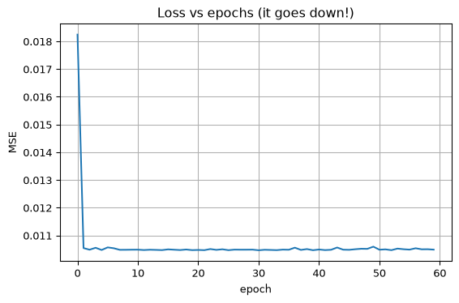

```python
def train(X, y, lr=0.05, batch_size=3, n_epochs=60, seed=0):
    n, m = X.shape
    rng = np.random.default_rng(seed)
    w = np.zeros(m); b = 0.0                 # init (Part II: start somewhere)
    history = []
    for epoch in range(n_epochs):
        idx = rng.permutation(n)             # shuffle -> different batches each epoch
        for start in range(0, n, batch_size):
            bi = idx[start:start+batch_size]
            Xb, yb = X[bi], y[bi]
            B = Xb.shape[0]
            resid  = Xb @ w + b - yb         # r = Xw + b - y      (Part I: matrix-vec)
            grad_w = (2.0/B) * (Xb.T @ resid)# ∇_w L = (2/B) Xᵀr    (sec-derive-matrix)
            grad_b = (2.0/B) * resid.sum()   # ∂L/∂b = (2/B) Σr     (sec-derive-matrix)
            w -= lr * grad_w                 # w ← w − η ∇_w L      (sec-gradient)
            b -= lr * grad_b                 # b ← b − η ∂L/∂b
        history.append(np.mean((X @ w + b - y)**2))   # full-data MSE this epoch
    return w, b, history

# a larger synthetic dataset so the fit can actually recover the true parameters
N = 2000
X_big = rng.normal(size=(N, 3))
y_big = X_big @ w_t + b_t + 0.1*rng.normal(size=N)

w_hat, b_hat, hist = train(X_big, y_big, lr=0.05, batch_size=64, n_epochs=60)
print("true    w =", w_t, " b = %.3f" % b_t)
print("learned w =", w_hat, " b = %.3f" % b_hat)

plt.figure(figsize=(6,4))
plt.plot(hist)
plt.xlabel("epoch"); plt.ylabel("MSE"); plt.title("Loss vs epochs (it goes down!)")
plt.grid(True); plt.tight_layout(); plt.show()
```

The learned $w,b$ recover the true values, and the loss curve decreases — the same behaviour you saw in HW1’s training plot, now from first principles.

## 4.3 Exercises

**Exercise 2 — shapes**

For a batch with $B=256$ samples and $m=943$ features, state the shapes of `Xb`, `resid`, `Xb.T`, and `grad_w`.

**Solution.** `Xb`: $256\times943$; `resid`: $256$; `Xb.T`: $943\times256$; `grad_w = Xb.T @ resid`: $943$ (one number per weight, matching `w`). The bias gradient is a single scalar.

**Exercise 3 — derive an L1-style gradient**

Suppose we used the **mean absolute error** $L=\frac1B\sum_i|r_i|$ instead of MSE. Using $\frac{d}{dt}|t| = \operatorname{sign}(t)$ and the chain rule, what is $\nabla_w L$?

**Solution.** $\dfrac{\partial L}{\partial w_j}=\dfrac1B\sum_i \operatorname{sign}(r_i)\,X_{ij} =\dfrac1B\big(X^\top \operatorname{sign}(r)\big)_j$, i.e. $\nabla_w L=\frac1B X^\top\operatorname{sign}(r)$. Same structure as MSE, but the residual is replaced by its sign — large errors no longer dominate (more robust to outliers; cf. HW1 limitation 3.5.7).

**Exercise 4 — the factor of 2**

Some textbooks define MSE as $\frac{1}{2B}\sum_i r_i^2$. What happens to `grad_w`, and does the trained model change?

**Solution.** The $\tfrac12$ cancels the $2$ from the power rule, giving $\nabla_w L=\frac1B X^\top r$ (no leading 2). The gradient is just rescaled by a constant, which is equivalent to halving the learning rate — with $\eta$ retuned the trained model is identical. The factor is cosmetic.

## 4.4 Recap

- **Linear algebra** gave us the model $h_\theta(x)=w^\top x+b$, its batched form $\hat y = Xw+b$, and the transpose identity $\big(X^\top r\big)_j=\sum_i X_{ij}r_i$.
- **Calculus** gave us the derivative as a slope, the chain-rule pattern *2 × residual × inner-slope*, and the gradient as the vector of partials pointing uphill.
- Combining them, the MSE gradient is $\nabla_w L=\frac{2}{B}X^\top r$ and $\partial L/\partial b=\frac{2}{B}\sum_i r_i$ — **exactly** the two `grad` lines in the HW1 loop — and gradient descent subtracts $\eta$ times those.

You now have the full chain from raw definitions to working code.